# Netherlands Yield Curve Modeling

## 2. Nelson-Siegel Model Implementation

The Nelson-Siegel model is a parsimonious model for fitting yield curves. It uses the following functional form:

$$y(t) = \beta_0 + \beta_1 \left(\frac{1 - e^{-\lambda t}}{\lambda t}\right) + \beta_2 \left(\frac{1 - e^{-\lambda t}}{\lambda t} - e^{-\lambda t}\right)$$

Where:

- $\beta_0$: Long-term yield level
- $\beta_1$: Short-term component
- $\beta_2$: Medium-term component
- $\lambda$: Decay parameter

```python
def nelson_siegel(t, beta0, beta1, beta2, lambda_param):
    """
    Nelson-Siegel yield curve model

    Parameters:
    t: time to maturity
    beta0: long-term yield level
    beta1: short-term component
    beta2: medium-term component
    lambda_param: decay parameter
    """
    t_safe = np.where(t == 0, 1e-10, t)

    term1 = (1 - np.exp(-lambda_param * t_safe)) / (lambda_param * t_safe)
    term2 = (1 - np.exp(-lambda_param * t_safe)) / (lambda_param * t_safe) - np.exp(-lambda_param * t_safe)

    return beta0 + beta1 * term1 + beta2 * term2

def nelson_siegel_objective(params, t, observed_yields):
    """
    Objective function for Nelson-Siegel optimization
    """
    beta0, beta1, beta2, lambda_param = params
    predicted_yields = nelson_siegel(t, beta0, beta1, beta2, lambda_param)
    return np.sum((observed_yields - predicted_yields)**2)

print("Fitting Nelson-Siegel model...")

#initial parameter guess
initial_params = [4.0, -2.0, -1.0, 1.0]
#bounds for optimization
bounds = [
    (0, 10),
    (-10, 10),
    (-10, 10),
    (0.1, 5)
] #long-term yield=0-10%, short-term component=-10-10%, medium-term component=-10-10%, decay parameter=0.1-5

result = minimize(
    nelson_siegel_objective,
    initial_params,
    args=(maturities, yields),
    method='L-BFGS-B',
    bounds=bounds,
    options={'maxiter': 1000}
)

beta0_fit, beta1_fit, beta2_fit, lambda_fit = result.x

print(f"Nelson-Siegel Model Results:")
print(f"β₀ (Long-term level): {beta0_fit:.4f}")
print(f"β₁ (Short-term component): {beta1_fit:.4f}")
print(f"β₂ (Medium-term component): {beta2_fit:.4f}")
print(f"λ (Decay parameter): {lambda_fit:.4f}")
print(f"Sum of Squared Errors: {result.fun:.6f}")

fitted_yields_ns = nelson_siegel(maturities, beta0_fit, beta1_fit, beta2_fit, lambda_fit)

comparison_df = pd.DataFrame({
    'Maturity': maturities,
    'Observed': yields,
    'Nelson-Siegel': fitted_yields_ns,
    'Difference': yields - fitted_yields_ns
})

print(f"\nFitted vs Observed Yields:")
print(comparison_df.round(4))
```

```
Fitting Nelson-Siegel model...
Nelson-Siegel Model Results:
β₀ (Long-term level): 3.3567
β₁ (Short-term component): -1.2671
β₂ (Medium-term component): 0.0000
λ (Decay parameter): 0.5830
Sum of Squared Errors: 0.046775

Fitted vs Observed Yields:
    Maturity  Observed  Nelson-Siegel  Difference
0       0.25      2.08         2.1776     -0.0976
1       0.50      2.28         2.2576      0.0224
2       1.00      2.48         2.3966      0.0834
3       2.00      2.68         2.6087      0.0713
4       3.00      2.78         2.7583      0.0217
5       5.00      2.88         2.9456     -0.0656
6       7.00      2.98         3.0515     -0.0715
7      10.00      3.08         3.1400     -0.0600
8      15.00      3.18         3.2118     -0.0318
9      20.00      3.28         3.2480      0.0320
10     30.00      3.38         3.2843      0.0957
```

## 3. Cubic-Spline Model Implementation

The cubic spline method interpolates between observed bond yields using piecewise cubic polynomials, ensuring smoothness at the knots.

```
Fitting Cubic-Spline model...
Cubic-Spline Model Results:
Sum of Squared Errors: 0.000000

Complete Comparison:
    Maturity  Observed  Nelson-Siegel  Difference  Cubic-Spline  \
0       0.25      2.08         2.1776     -0.0976          2.08
1       0.50      2.28         2.2576      0.0224          2.28
2       1.00      2.48         2.3966      0.0834          2.48
3       2.00      2.68         2.6087      0.0713          2.68
4       3.00      2.78         2.7583      0.0217          2.78
5       5.00      2.88         2.9456     -0.0656          2.88
6       7.00      2.98         3.0515     -0.0715          2.98
7      10.00      3.08         3.1400     -0.0600          3.08
8      15.00      3.18         3.2118     -0.0318          3.18
9      20.00      3.28         3.2480      0.0320          3.28
10     30.00      3.38         3.2843      0.0957          3.38

    NS Difference  CS Difference
0         -0.0976            0.0
1          0.0224            0.0
2          0.0834            0.0
3          0.0713            0.0
4          0.0217            0.0
5         -0.0656            0.0
6         -0.0715            0.0
7         -0.0600            0.0
8         -0.0318            0.0
9          0.0320            0.0
10         0.0957            0.0
```

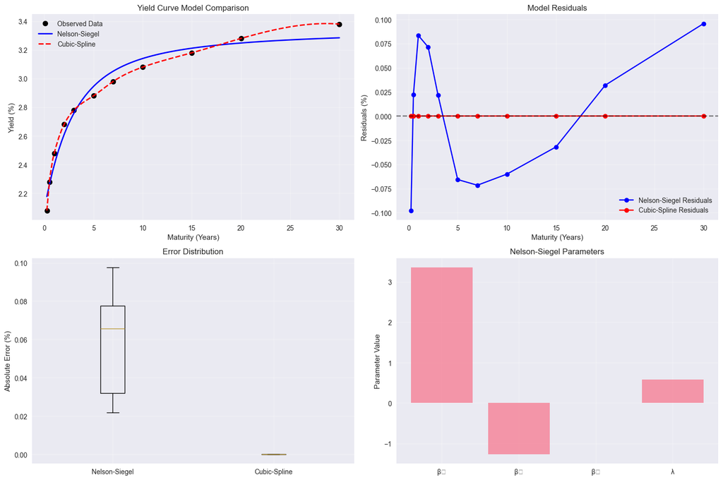

```python
print("Fitting Cubic-Spline model...")

cs = CubicSpline(maturities, yields)

fitted_yields_cs = cs(maturities)

sse_cs = np.sum((yields - fitted_yields_cs)**2)

print(f"Cubic-Spline Model Results:")
print(f"Sum of Squared Errors: {sse_cs:.6f}")

comparison_df['Cubic-Spline'] = fitted_yields_cs
comparison_df['NS Difference'] = yields - fitted_yields_ns
comparison_df['CS Difference'] = yields - fitted_yields_cs

print(f"\nComplete Comparison:")
print(comparison_df.round(4))

t_smooth = np.linspace(maturities.min(), maturities.max(), 100)
y_smooth_ns = nelson_siegel(t_smooth, beta0_fit, beta1_fit, beta2_fit, lambda_fit)
y_smooth_cs = cs(t_smooth)

plt.figure(figsize=(15, 10))

plt.subplot(2, 2, 1)
plt.plot(maturities, yields, 'ko', markersize=8, label='Observed Data', linewidth=2)
plt.plot(t_smooth, y_smooth_ns, 'b-', linewidth=2, label='Nelson-Siegel')
plt.plot(t_smooth, y_smooth_cs, 'r--', linewidth=2, label='Cubic-Spline')
plt.xlabel('Maturity (Years)')
plt.ylabel('Yield (%)')
plt.title('Yield Curve Model Comparison')
plt.legend()
plt.grid(True, alpha=0.3)

plt.subplot(2, 2, 2)
plt.plot(maturities, yields - fitted_yields_ns, 'bo-', label='Nelson-Siegel Residuals')
plt.plot(maturities, yields - fitted_yields_cs, 'ro-', label='Cubic-Spline Residuals')
plt.axhline(y=0, color='k', linestyle='--', alpha=0.5)
plt.xlabel('Maturity (Years)')
plt.ylabel('Residuals (%)')
plt.title('Model Residuals')
plt.legend()
plt.grid(True, alpha=0.3)

plt.subplot(2, 2, 3)
errors = [abs(yields - fitted_yields_ns), abs(yields - fitted_yields_cs)]
plt.boxplot(errors, labels=['Nelson-Siegel', 'Cubic-Spline'])
plt.ylabel('Absolute Error (%)')
plt.title('Error Distribution')
plt.grid(True, alpha=0.3)

plt.subplot(2, 2, 4)
params = ['β₀', 'β₁', 'β₂', 'λ']
values = [beta0_fit, beta1_fit, beta2_fit, lambda_fit]
plt.bar(params, values, alpha=0.7)
plt.ylabel('Parameter Value')
plt.title('Nelson-Siegel Parameters')
plt.grid(True, alpha=0.3)

plt.tight_layout()
plt.show()
```

## 4. Model Comparison and Analysis

### 4.1 Fit Comparison

```python
#calculate performance metrics with extra step=cross-validation to show overfitting
from sklearn.model_selection import KFold
from sklearn.metrics import mean_squared_error, r2_score

def calculate_metrics(observed, predicted):
    """Calculate various performance metrics"""
    mse = np.mean((observed - predicted)**2)
    rmse = np.sqrt(mse)
    mae = np.mean(np.abs(observed - predicted))
    mape = np.mean(np.abs((observed - predicted) / observed)) * 100
    r_squared = 1 - (np.sum((observed - predicted)**2) / np.sum((observed - np.mean(observed))**2))
    return mse, rmse, mae, mape, r_squared

def cross_validate_cubic_spline(X, y, n_splits=3):
    """Cross-validate cubic spline to get realistic performance metrics"""
    kf = KFold(n_splits=n_splits, shuffle=True, random_state=42)
    rmse_scores = []
    r2_scores = []

    for train_idx, test_idx in kf.split(X):
        X_train, X_test = X[train_idx], X[test_idx]
        y_train, y_test = y[train_idx], y[test_idx]

        cs = CubicSpline(X_train, y_train)
        y_pred = cs(X_test)

        rmse_scores.append(np.sqrt(mean_squared_error(y_test, y_pred)))
        r2_scores.append(r2_score(y_test, y_pred))

    return np.mean(rmse_scores), np.mean(r2_scores)

mse_ns, rmse_ns, mae_ns, mape_ns, r2_ns = calculate_metrics(yields, fitted_yields_ns)

# Calculate realistic metrics for Cubic-Spline using cross-validation
rmse_cs_cv, r2_cs_cv = cross_validate_cubic_spline(maturities, yields)

mse_cs, rmse_cs, mae_cs, mape_cs, r2_cs = calculate_metrics(yields, fitted_yields_cs)

metrics_df = pd.DataFrame({
    'Metric': ['MSE', 'RMSE', 'MAE', 'MAPE (%)', 'R²'],
    'Nelson-Siegel': [mse_ns, rmse_ns, mae_ns, mape_ns, r2_ns],
    'Cubic-Spline (In-sample)': [mse_cs, rmse_cs, mae_cs, mape_cs, r2_cs],
    'Cubic-Spline (Cross-val)': ['N/A', f'{rmse_cs_cv:.6f}', 'N/A', 'N/A', f'{r2_cs_cv:.6f}']
})

print("Model Performance Comparison:")
print(metrics_df.round(6))

print(f"\nModel Performance Summary:")
print(f"Nelson-Siegel - RMSE: {rmse_ns:.6f}, R²: {r2_ns:.6f}")
print(f"Cubic-Spline (Cross-val) - RMSE: {rmse_cs_cv:.6f}, R²: {r2_cs_cv:.6f}")
print(f"\nNote: Cubic-Spline in-sample metrics show overfitting (perfect fit)")
print(f"Cross-validation provides more realistic performance estimates")

if rmse_ns < rmse_cs_cv:
    print("✓ Nelson-Siegel has better out-of-sample performance")
else:
    print("✓ Cubic-Spline has better out-of-sample performance")

if r2_ns > r2_cs_cv:
    print("✓ Nelson-Siegel is more robust (higher cross-validated R²)")
else:
    print("✓ Cubic-Spline is more robust (higher cross-validated R²)")
```

```
Model Performance Comparison:
     Metric  Nelson-Siegel  Cubic-Spline (In-sample) Cubic-Spline (Cross-val)
0       MSE       0.004252                       0.0                      N/A
1      RMSE       0.065209                       0.0                 0.273926
2       MAE       0.059381                       0.0                      N/A
3  MAPE (%)       2.174379                       0.0                      N/A
4        R²       0.972920                       1.0                 0.281414

Model Performance Summary:
Nelson-Siegel - RMSE: 0.065209, R²: 0.972920
Cubic-Spline (Cross-val) - RMSE: 0.273926, R²: 0.281414

Note: Cubic-Spline in-sample metrics show overfitting (perfect fit)
Cross-validation provides more realistic performance estimates
✓ Nelson-Siegel has better out-of-sample performance
✓ Nelson-Siegel is more robust (higher cross-validated R²)
```

### 4.2 Interpretation Analysis

Let's analyze what the model parameters tell us about the Netherlands yield curve:

```
Nelson-Siegel Parameter Interpretation:
==================================================
β₀ (Long-term yield level): 3.3567%
β₁ (Short-term component): -1.2671%
β₂ (Medium-term component): 0.0000%
λ (Decay parameter): 0.5830

Yield Curve Shape Analysis:
Short-term yield (1Y): 2.3966%
Medium-term yield (5Y): 2.9456%
Long-term yield (10Y): 3.1400%
Very long-term yield (30Y): 3.2843%

Yield Curve Shape Analysis:
Short-term yield (1Y): 2.3966%
Medium-term yield (5Y): 2.9456%
Long-term yield (10Y): 3.1400%
Very long-term yield (30Y): 3.2843%
```

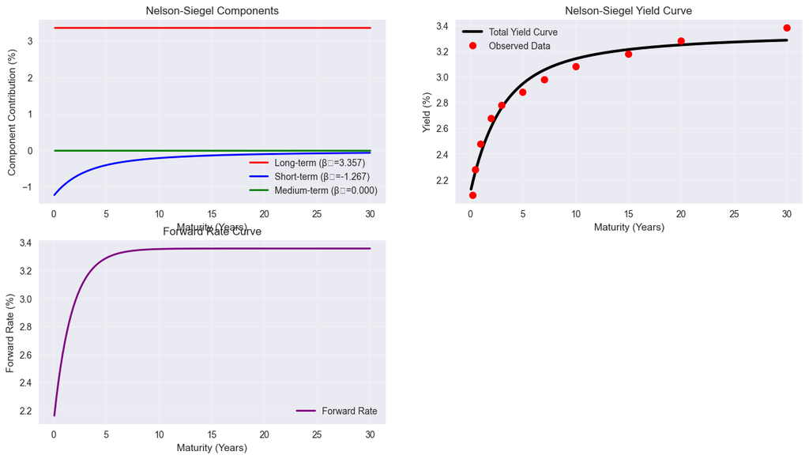

```python
print("Nelson-Siegel Parameter Interpretation:")
print("="*50)

print(f"β₀ (Long-term yield level): {beta0_fit:.4f}%")
print(f"β₁ (Short-term component): {beta1_fit:.4f}%")
print(f"β₂ (Medium-term component): {beta2_fit:.4f}%")
print(f"λ (Decay parameter): {lambda_fit:.4f}")

print(f"\nYield Curve Shape Analysis:")
print(f"Short-term yield (1Y): {nelson_siegel(1, beta0_fit, beta1_fit, beta2_fit, lambda_fit):.4f}%")
print(f"Medium-term yield (5Y): {nelson_siegel(5, beta0_fit, beta1_fit, beta2_fit, lambda_fit):.4f}%")
print(f"Long-term yield (10Y): {nelson_siegel(10, beta0_fit, beta1_fit, beta2_fit, lambda_fit):.4f}%")
print(f"Very long-term yield (30Y): {nelson_siegel(30, beta0_fit, beta1_fit, beta2_fit, lambda_fit):.4f}%")


t_analysis = np.linspace(0.1, 30, 300)
long_term = np.full_like(t_analysis, beta0_fit)
short_term = beta1_fit * (1 - np.exp(-lambda_fit * t_analysis)) / (lambda_fit * t_analysis)
medium_term = beta2_fit * ((1 - np.exp(-lambda_fit * t_analysis)) / (lambda_fit * t_analysis) - np.exp(-lambda_fit * t_analysis))


plt.figure(figsize=(15, 8))

plt.subplot(2, 2, 1)
plt.plot(t_analysis, long_term, 'r-', label=f'Long-term (β₀={beta0_fit:.3f})', linewidth=2)
plt.plot(t_analysis, short_term, 'b-', label=f'Short-term (β₁={beta1_fit:.3f})', linewidth=2)
plt.plot(t_analysis, medium_term, 'g-', label=f'Medium-term (β₂={beta2_fit:.3f})', linewidth=2)
plt.xlabel('Maturity (Years)')
plt.ylabel('Component Contribution (%)')
plt.title('Nelson-Siegel Components')
plt.legend()
plt.grid(True, alpha=0.3)

plt.subplot(2, 2, 2)
plt.plot(t_analysis, long_term + short_term + medium_term, 'k-', linewidth=3, label='Total Yield Curve')
plt.plot(maturities, yields, 'ro', markersize=8, label='Observed Data')
plt.xlabel('Maturity (Years)')
plt.ylabel('Yield (%)')
plt.title('Nelson-Siegel Yield Curve')
plt.legend()
plt.grid(True, alpha=0.3)

plt.subplot(2, 2, 3)

forward_rate = beta0_fit + beta1_fit * np.exp(-lambda_fit * t_analysis) + beta2_fit * lambda_fit * t_analysis * np.exp(-lambda_fit * t_analysis)
plt.plot(t_analysis, forward_rate, 'purple', linewidth=2, label='Forward Rate')
plt.xlabel('Maturity (Years)')
plt.ylabel('Forward Rate (%)')
plt.title('Forward Rate Curve')
plt.legend()
plt.grid(True, alpha=0.3)


print(f"\nYield Curve Shape Analysis:")
print(f"Short-term yield (1Y): {nelson_siegel(1, beta0_fit, beta1_fit, beta2_fit, lambda_fit):.4f}%")
print(f"Medium-term yield (5Y): {nelson_siegel(5, beta0_fit, beta1_fit, beta2_fit, lambda_fit):.4f}%")
print(f"Long-term yield (10Y): {nelson_siegel(10, beta0_fit, beta1_fit, beta2_fit, lambda_fit):.4f}%")
print(f"Very long-term yield (30Y): {nelson_siegel(30, beta0_fit, beta1_fit, beta2_fit, lambda_fit):.4f}%")
```